# Practical Machine Learning Assignment

Iain Read

## Overview

The goal of this project is to build a model which predicts the manner in which bicep curls were performed, using movement data in the WLE dataset.

## Exploration and Cleaning

```r
training <- read.csv("pml-training.csv")
testing <- read.csv("pml-testing.csv")

dim(training)
```

```
## [1] 19622   160
```

```r
dim(testing)
```

```
## [1]  20 160
```

The training data set has 19622 observations of 160 features, while the testing dataset has 20 observations of 160 features. It was noted that the outcome variable, classe, is not included in the testing set, and is instead replaced with the problem_id feature.

Exploration of the data showed 62 columns with near zero variance, and 41 with 19216 missing values. These are unlikely to have much predictive power and so they were removed from the training set. Also removed were the index variables, X and num_window, and the three timestamp variables.

```r
training$user_name <- as.factor(training$user_name)
training$classe <- as.factor(training$classe)
testing$user_name <- as.factor(testing$user_name)

colsToRemove <- c("raw_timestamp_part_1", "raw_timestamp_part_2", "cvtd_timestamp", "X", "num_window")
naCols <- colnames(training[, colSums(is.na(training)) > 0.3*nrow(training)])
nzvCols <- nearZeroVar(training, names=T)
colsToRemove <- c(colsToRemove, nzvCols, naCols)

cleanup <- function(df, colsToRemove){
    df %<>% select(-all_of(colsToRemove))
}
training2 <- cleanup(training, colsToRemove)
```

```r
training3 <- training2 %>% select(-c("user_name", "classe"))
training3Corr <- cor(training3)
corrIndices <- findCorrelation(training3Corr, cutoff = 0.5, exact=T)
corrCols <- colnames(training3[corrIndices])
training2 <- cleanup(training2, corrCols)
colsToRemove <- c(colsToRemove, corrCols)
testing2 <- cleanup(testing, colsToRemove)
```

Inspection of cleaned data showed a bias in the training data towards class A, the correct method for lifting. Class A accounts for 28.4% of the records, while class D accounts for only 16.4%. While large, this difference is not necessarily significant enough to affect the model if the predictors for the two classes are sufficiently different. Given that we also have over 3000 records for the least represented class, the decision was taken not to undersample class A.

Figure 1: Table of proportions (%) of each class in the data set

```r
tab <- table(training2$classe)
round(tab/19622, 3)*100
```

```
##
##    A    B    C    D    E
## 28.4 19.4 17.4 16.4 18.4
```

The training data set was split into a training set (80%) and a validation set (20%)

```r
Train <- createDataPartition(training2$classe, p=0.8, list=F)
trainingSet <- training2[ Train, ]
validationSet <- training2 [-Train, ]
```

## Cross Validation

K-fold cross validation was performed using 5 folds.

```r
ctrl <- trainControl(method = "cv", number = 5)
```

## Modelling

A random forest model was selected to fit the data, since there are many variables and this is a classification problem, rather than a regression problem.

```r
rfMod <- train(classe ~ ., data=trainingSet, method="rf", trControl = ctrl)
```

The achieved accuracy of the final model is 99.99% on the training set.

```r
confusionMatrix(predict(rfMod), trainingSet$classe)
```

```
## Confusion Matrix and Statistics
##
##           Reference
## Prediction    A    B    C    D    E
##          A 4464    0    0    0    0
##          B    0 3038    0    0    0
##          C    0    0 2737    1    0
##          D    0    0    1 2572    0
##          E    0    0    0    0 2886
##
## Overall Statistics
##
##                Accuracy : 0.9999
##                  95% CI : (0.9995, 1)
##     No Information Rate : 0.2843
##     P-Value [Acc > NIR] : < 2.2e-16
##
##                   Kappa : 0.9998
##
##  Mcnemar's Test P-Value : NA
##
## Statistics by Class:
##
##                      Class: A Class: B Class: C Class: D Class: E
## Sensitivity            1.0000   1.0000   0.9996   0.9996   1.0000
## Specificity            1.0000   1.0000   0.9999   0.9999   1.0000
## Pos Pred Value         1.0000   1.0000   0.9996   0.9996   1.0000
## Neg Pred Value         1.0000   1.0000   0.9999   0.9999   1.0000
## Prevalence             0.2843   0.1935   0.1744   0.1639   0.1838
## Detection Rate         0.2843   0.1935   0.1743   0.1638   0.1838
## Detection Prevalence   0.2843   0.1935   0.1744   0.1639   0.1838
## Balanced Accuracy      1.0000   1.0000   0.9998   0.9998   1.0000
```

```r
pred <- predict(rfMod, newdata=validationSet)
confusionMatrix(pred, validationSet$classe)
```

```
## Confusion Matrix and Statistics
##
##           Reference
## Prediction    A    B    C    D    E
##          A 1113   13    1    0    0
##          B    1  738    7    0    0
##          C    0    6  674   25    1
##          D    1    1    1  617    2
##          E    1    1    1    1  718
##
## Overall Statistics
##
##                Accuracy : 0.9839
##                  95% CI : (0.9795, 0.9876)
##     No Information Rate : 0.2845
##     P-Value [Acc > NIR] : < 2.2e-16
##
##                   Kappa : 0.9797
##
##  Mcnemar's Test P-Value : 4.031e-05
##
## Statistics by Class:
##
##                      Class: A Class: B Class: C Class: D Class: E
## Sensitivity            0.9973   0.9723   0.9854   0.9596   0.9958
## Specificity            0.9950   0.9975   0.9901   0.9985   0.9988
## Pos Pred Value         0.9876   0.9893   0.9547   0.9920   0.9945
## Neg Pred Value         0.9989   0.9934   0.9969   0.9921   0.9991
## Prevalence             0.2845   0.1935   0.1744   0.1639   0.1838
## Detection Rate         0.2837   0.1881   0.1718   0.1573   0.1830
## Detection Prevalence   0.2873   0.1902   0.1800   0.1586   0.1840
## Balanced Accuracy      0.9962   0.9849   0.9878   0.9790   0.9973
```

## Importances

The importances attached to each feature in the dataset are plotted below. It is clear that pitch_forearm is the most important feature, but many of the features in the dataset have significant importance. There is a clear step down in importance for all values of the user_name feature, so it is likely that this could have been excluded from the model.

Figure 2: Feature importance plot

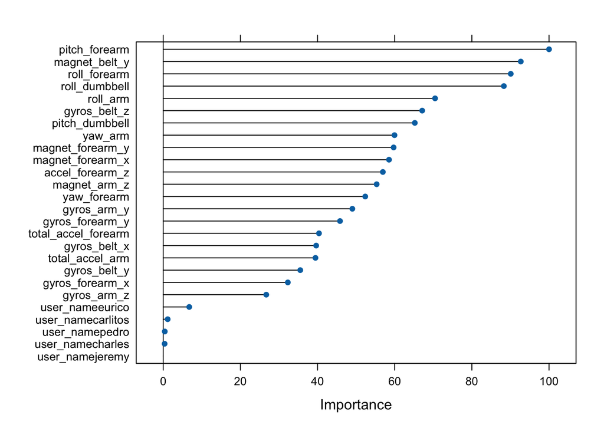

```r
imp <- varImp(rfMod)
importance <- data.frame(imp$importance)
plot(imp)
```

## Prediction

Having been trained and validated, the model was then used to make predictions on the test set, as below.

```r
predictions <- predict(rfMod, newdata=testing2)
predictions
```

```
##  [1] B A B A A E D B A A B C B A E E A B B B
## Levels: A B C D E
```